# Practical Lab 1 - Univariate Linear Regression on the California Housing Prices Dataset

## Step 2. Getting the Data - hyperlink to the source and load into Pandas.

```python
import pandas as pd
from sklearn.datasets import fetch_california_housing

# Get the California housing dataset
housing = fetch_california_housing(as_frame=True)

# Combine features (independent variables) and target (dependent variable) into a DataFrame
df = pd.DataFrame(data=housing.data, columns=housing.feature_names)
df['median_house_value'] = housing.target

# Display the first few rows of the DataFrame
print(df.head())
```

```
   MedInc  HouseAge  AveRooms  AveBedrms  Population  AveOccup  Latitude  \
0  8.3252   41.0000    6.9841     1.0238    322.0000    2.5556   37.8800
1  8.3014   21.0000    6.2381     0.9719   2401.0000    2.1098   37.8600
2  7.2574   52.0000    8.2881     1.0734    496.0000    2.8023   37.8500
3  5.6431   52.0000    5.8174     1.0731    558.0000    2.5479   37.8500
4  3.8462   52.0000    6.2819     1.0811    565.0000    2.1815   37.8500

   Longitude  median_house_value
0  -122.2300              4.5260
1  -122.2200              3.5850
2  -122.2400              3.5210
3  -122.2500              3.4130
4  -122.2500              3.4220
```

## Step 3. Exploratory Data Analysis (EDA)

(1) Explore statistics (e.g., using Pandas `describe` function)

```python
import seaborn as sns
import matplotlib.pyplot as plt

# Display statistics dataset
print("Descriptive Statistics for the Dataset:")
print(df.describe())
print("\n")

# Check for missing values
print("Missing Values Check:")
print(df.isnull().sum())
print("\n")
```

```
Descriptive Statistics for the Dataset:
          MedInc   HouseAge   AveRooms  AveBedrms  Population   AveOccup  \
count 20640.0000 20640.0000 20640.0000 20640.0000  20640.0000 20640.0000
mean      3.8707    28.6395     5.4290     1.0967   1425.4767     3.0707
std       1.8998    12.5856     2.4742     0.4739   1132.4621    10.3860
min       0.4999     1.0000     0.8462     0.3333      3.0000     0.6923
25%       2.5634    18.0000     4.4407     1.0061    787.0000     2.4297
50%       3.5348    29.0000     5.2291     1.0488   1166.0000     2.8181
75%       4.7432    37.0000     6.0524     1.0995   1725.0000     3.2823
max      15.0001    52.0000   141.9091    34.0667  35682.0000  1243.3333

        Latitude  Longitude  median_house_value
count 20640.0000 20640.0000          20640.0000
mean     35.6319  -119.5697              2.0686
std       2.1360     2.0035              1.1540
min      32.5400  -124.3500              0.1500
25%      33.9300  -121.8000              1.1960
50%      34.2600  -118.4900              1.7970
75%      37.7100  -118.0100              2.6472
max      41.9500  -114.3100              5.0000


Missing Values Check:
MedInc                0
HouseAge              0
AveRooms              0
AveBedrms             0
Population            0
AveOccup              0
Latitude              0
Longitude             0
median_house_value    0
dtype: int64
```

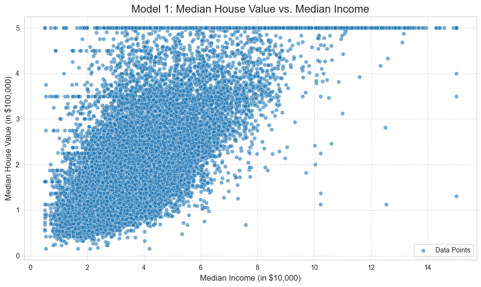

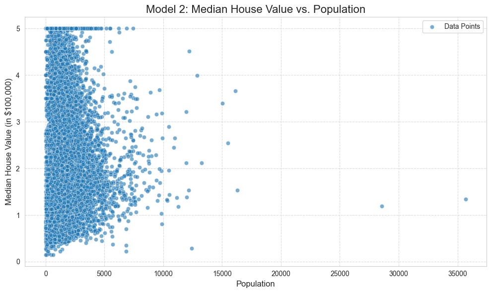

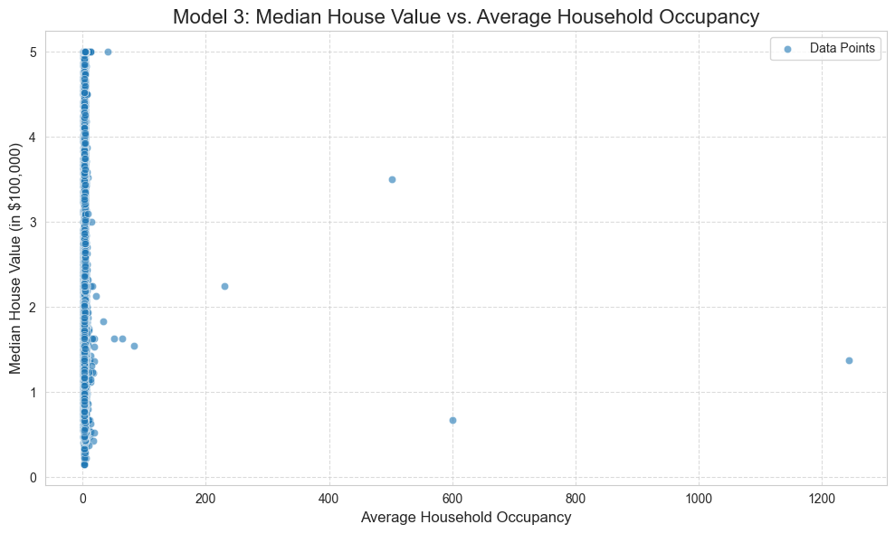

```python
# Set the style for seaborn plots
sns.set_style("whitegrid")

# Create the first scatter plot: Median House Value vs. Median Income
plt.figure(figsize=(10,6))
sns.scatterplot(x='MedInc', y='median_house_value', data=df, alpha=0.6, label='Data Points')
plt.title('Model 1: Median House Value vs. Median Income', fontsize=16)
plt.xlabel('Median Income (in $10,000)', fontsize=12)
plt.ylabel('Median House Value (in $100,000)', fontsize=12)
plt.grid(True, linestyle='--', alpha=0.7)
plt.tight_layout()
plt.show()

# Create the second scatter plot: Median House Value vs. Population
plt.figure(figsize=(10,6))
sns.scatterplot(x='Population', y='median_house_value', data=df, alpha=0.6, label='Data Points')
plt.title('Model 2: Median House Value vs. Population', fontsize=16)
plt.xlabel('Population', fontsize=12)
plt.ylabel('Median House Value (in $100,000)', fontsize=12)
plt.grid(True, linestyle='--', alpha=0.7)
plt.tight_layout()
plt.show()

# Create the third scatter plot: Median House Value vs. Number of Households
plt.figure(figsize=(10,6))
sns.scatterplot(x='AveOccup', y='median_house_value', data=df, alpha=0.6, label='Data Points')
plt.title('Model 3: Median House Value vs. Average Household Occupancy', fontsize=16)
plt.xlabel('Average Household Occupancy', fontsize=12)
plt.ylabel('Median House Value (in $100,000)', fontsize=12)
plt.grid(True, linestyle='--', alpha=0.7)
plt.tight_layout()
plt.show()
```

Observation:

- Median House Value vs. Median Income

From this plot, we can see that this is a positive linear. When the Median Income increases, the Median House Value will increase. When the Median House Value is very high, that have some outliers.

- Median House Value vs. Population

From this plot, it is weakly linear. We can not futhre analyze by linear Regression.

- Median House Value vs. Average Household Occupancy

From this plot, it can not to shown linear. We can not analyze by linear Regression.

Insight for Linear Regression:

Compare these three models. In the Median House Value vs. Median Income model, we can expect a high R-squared value and a low Mean Squared Error (MSE).

## Step 4. Run three linear regressions

The Formula of linear regression (simple version): $$ y = \beta_0 + \beta_1 x + \epsilon $$

Where:

- y: `median_house_value` (Dependent variable)
- x: `MedInc` or `Population` or `AveOccup` (Independent variable)
- β₀: Intercept
- β₁: Slope
- ϵ: Error term

```python
from sklearn.linear_model import LinearRegression
from sklearn.metrics import mean_squared_error, mean_absolute_error

# Define the dependent variables
y = df['median_house_value']

# Store results
results = {}

# Display Linear Regression Model 1: median house value vs. median income
print("Running Linear Regression Model 1: Median House Value vs. Median Income")
X_medinc = df[['MedInc']] # Features must be 2D array, so use double brackets or .values.reshape(-1, 1)

# Initialize the model
model_medinc = LinearRegression()

# Fit the model
model_medinc.fit(X_medinc, y)

# Make predictions
y_pred_medinc = model_medinc.predict(X_medinc)

# Calculate MSE and MAE metrics
mse_medinc = mean_squared_error(y, y_pred_medinc)
mae_medinc = mean_absolute_error(y, y_pred_medinc)

# Store results
results['MedInc'] = {
    'model': model_medinc,
    'intercept': model_medinc.intercept_,
    'slope': model_medinc.coef_[0],
    'mse': mse_medinc,
    'mae': mae_medinc,
    'y_pred': y_pred_medinc
}

# Display the results
print(f"Intercept: {model_medinc.intercept_:.4f}")
print(f"Slope (MedInc): {model_medinc.coef_[0]:.4f}")
print(f"Mean Squared Error: {mse_medinc:.4f}")
print(f"Mean Absolute Error: {mae_medinc:.4f}\n")


# Display Linear Regression Model 2: median house value vs. population
print("Running Linear Regression Model 2: Median House Value vs. Population")
X_population = df[['Population']]

# Initialize the model, fit the model, make predictions
model_population = LinearRegression()
model_population.fit(X_population, y)
y_pred_population = model_population.predict(X_population)

# Calculate MSE and MAE metrics
mse_population = mean_squared_error(y, y_pred_population)
mae_population = mean_absolute_error(y, y_pred_population)

# Store results
results['Population'] = {
    'model': model_population,
    'intercept': model_population.intercept_,
    'slope': model_population.coef_[0],
    'mse': mse_population,
    'mae': mae_population,
    'y_pred': y_pred_population
}

# Display the results
print(f"Intercept: {model_population.intercept_:.4f}")
print(f"Slope (Population): {model_population.coef_[0]:.4f}")
print(f"Mean Squared Error: {mse_population:.4f}")
print(f"Mean Absolute Error: {mae_population:.4f}\n")


# Display Linear Regression Model 3: median house value vs. Average Household Occupancy
print("Running Linear Regression Model 3: Median House Value vs. Average Household Occupancy")
X_aveoccup = df[['AveOccup']]

# Initialize the model, fit the model, make predictions
model_aveoccup = LinearRegression()
model_aveoccup.fit(X_aveoccup, y)
y_pred_aveoccup = model_aveoccup.predict(X_aveoccup)

# Calculate MSE and MAE metrics
mse_aveoccup = mean_squared_error(y, y_pred_aveoccup)
mae_aveoccup = mean_absolute_error(y, y_pred_aveoccup)

# Store results
results['AveOccup'] = {
    'model': model_aveoccup,
    'intercept': model_aveoccup.intercept_,
    'slope': model_aveoccup.coef_[0],
    'mse': mse_aveoccup,
    'mae': mae_aveoccup,
    'y_pred': y_pred_aveoccup
}

# Display the results
print(f"Intercept: {model_aveoccup.intercept_:.4f}")
print(f"Slope (AveOccup): {model_aveoccup.coef_[0]:.4f}")
print(f"Mean Squared Error: {mse_aveoccup:.4f}")
print(f"Mean Absolute Error: {mae_aveoccup:.4f}\n")
```

```
Running Linear Regression Model 1: Median House Value vs. Median Income
Intercept: 0.4509
Slope (MedInc): 0.4179
Mean Squared Error: 0.7011
Mean Absolute Error: 0.6263

Running Linear Regression Model 2: Median House Value vs. Population
Intercept: 2.1044
Slope (Population): -0.0000
Mean Squared Error: 1.3307
Mean Absolute Error: 0.9115

Running Linear Regression Model 3: Median House Value vs. Average Household Occupancy
Intercept: 2.0767
Slope (AveOccup): -0.0026
Mean Squared Error: 1.3308
Mean Absolute Error: 0.9113
```

## Step 5. In a single table for all three linear regressions

Regression model includes:

- Intercept
- Slope
- MSE (Mean Squared Error)
- MAE (Mean Absolute Error)

```python
print("Linear Regression Model Table:")

# Data put in table
data_for_table = []
for model_name, model_results in results.items():
    data_for_table.append({
        'Independent Variable': model_name,
        'Intercept': model_results['intercept'],
        'Slope': model_results['slope'],
        'Mean Squared Error (MSE)': model_results['mse'],
        'Mean Absolute Error (MAE)': model_results['mae']
    })

# Create Pandas DataFrame
table_df = pd.DataFrame(data_for_table)

# Setting the 'Independent Variable' for index
table_df.set_index('Independent Variable', inplace=True)

# Setting to display float format
pd.options.display.float_format = '{:.4f}'.format

# Display the table
print(table_df)
```

```
Linear Regression Model Table:
                      Intercept   Slope  Mean Squared Error (MSE)  \
Independent Variable
MedInc                   0.4509  0.4179                    0.7011
Population               2.1044 -0.0000                    1.3307
AveOccup                 2.0767 -0.0026                    1.3308

                      Mean Absolute Error (MAE)
Independent Variable
MedInc                                   0.6263
Population                               0.9115
AveOccup                                 0.9113
```

## Step 6. Plot the resulting line on top of the scatter data for each of the three models

Using a text box and the plotting library to implementation models.

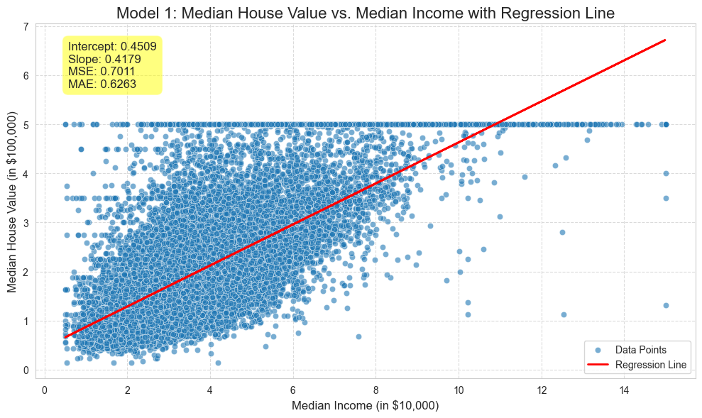

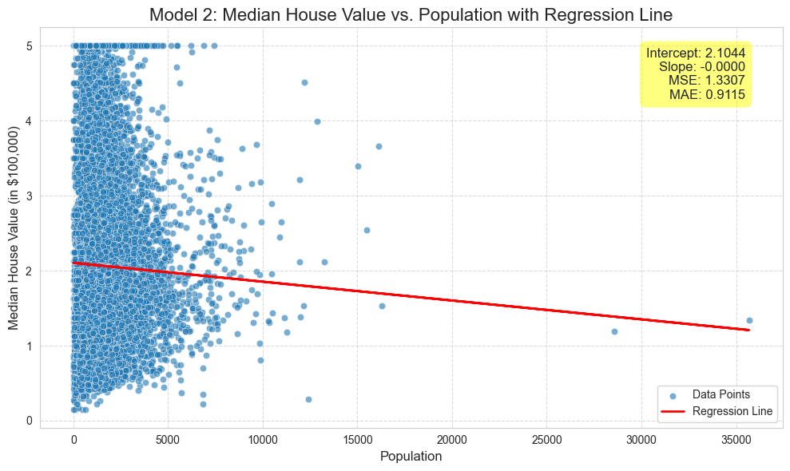

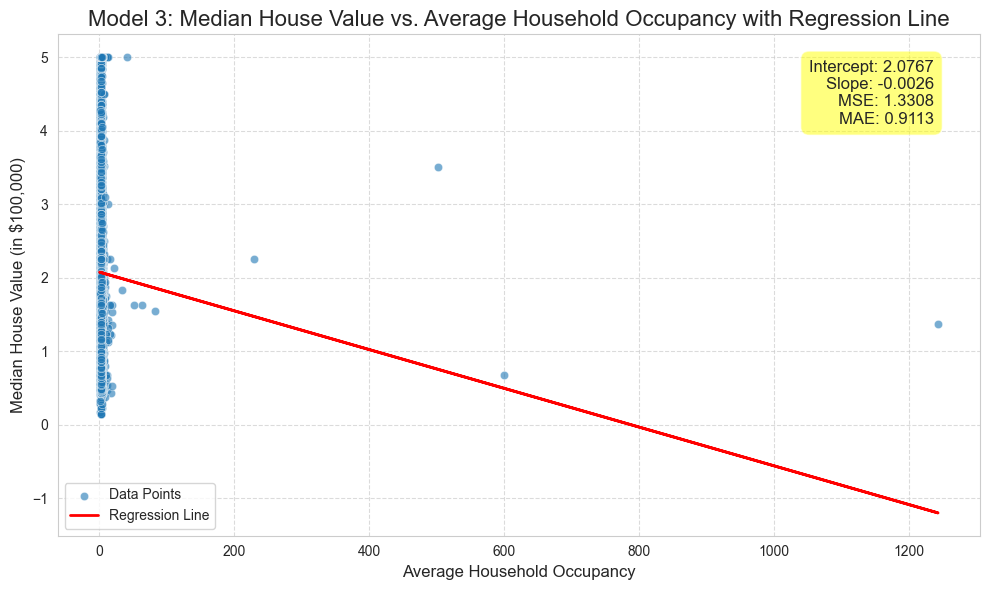

```python
import numpy as np

# Set the style for seaborn plots
sns.set_style("whitegrid")

# Model 1: Median House Value vs. Median Income
plt.figure(figsize=(10, 6))
sns.scatterplot(x='MedInc', y='median_house_value', data=df, alpha=0.6, label='Data Points')

# Plot regression line
plt.plot(X_medinc, results['MedInc']['y_pred'], color='red', linewidth=2, label='Regression Line')

# Get parameters
intercept = results['MedInc']['intercept']
slope = results['MedInc']['slope']
mse = results['MedInc']['mse']
mae = results['MedInc']['mae']

# Display Model 1: Median House Value vs. Median Income
plt.text(0.05, 0.95,
         f'Intercept: {intercept:.4f}\nSlope: {slope:.4f}\nMSE: {mse:.4f}\nMAE: {mae:.4f}',
         transform=plt.gca().transAxes, # Translate the coordinates, so that x=0.05, y=0.95 means the 5% and 95% positions in the upper left corner of the chart
         fontsize=12, verticalalignment='top', bbox=dict(boxstyle='round,pad=0.5', fc='yellow', alpha=0.5))

plt.title('Model 1: Median House Value vs. Median Income with Regression Line', fontsize=16)
plt.xlabel('Median Income (in $10,000)', fontsize=12)
plt.ylabel('Median House Value (in $100,000)', fontsize=12)
plt.legend()
plt.grid(True, linestyle='--', alpha=0.7)
plt.tight_layout()
plt.show()


# Model 2: Median House Value vs. Population
plt.figure(figsize=(10, 6))
sns.scatterplot(x='Population', y='median_house_value', data=df, alpha=0.6, label='Data Points')

# Plot regression line
plt.plot(X_population, results['Population']['y_pred'], color='red', linewidth=2, label='Regression Line')

# Get parameters
intercept = results['Population']['intercept']
slope = results['Population']['slope']
mse = results['Population']['mse']
mae = results['Population']['mae']

# Display Model 2: Median House Value vs. Population
plt.text(0.95, 0.95,
         f'Intercept: {intercept:.4f}\nSlope: {slope:.4f}\nMSE: {mse:.4f}\nMAE: {mae:.4f}',
         transform=plt.gca().transAxes,
         fontsize=12, verticalalignment='top', horizontalalignment='right', bbox=dict(boxstyle='round,pad=0.5', fc='yellow', alpha=0.5))

plt.title('Model 2: Median House Value vs. Population with Regression Line', fontsize=16)
plt.xlabel('Population', fontsize=12)
plt.ylabel('Median House Value (in $100,000)', fontsize=12)
plt.legend()
plt.grid(True, linestyle='--', alpha=0.7)
plt.tight_layout()
plt.show()


# Model 3: Median House Value vs. Average Household Occupancy
plt.figure(figsize=(10, 6))
sns.scatterplot(x='AveOccup', y='median_house_value', data=df, alpha=0.6, label='Data Points')

# Plot regression line
plt.plot(X_aveoccup, results['AveOccup']['y_pred'], color='red', linewidth=2, label='Regression Line')

# Get parameters
intercept = results['AveOccup']['intercept']
slope = results['AveOccup']['slope']
mse = results['AveOccup']['mse']
mae = results['AveOccup']['mae']

# Display Model 3: Median House Value vs. Average Household Occupancy
plt.text(0.95, 0.95,
         f'Intercept: {intercept:.4f}\nSlope: {slope:.4f}\nMSE: {mse:.4f}\nMAE: {mae:.4f}',
         transform=plt.gca().transAxes,
         fontsize=12, verticalalignment='top', horizontalalignment='right', bbox=dict(boxstyle='round,pad=0.5', fc='yellow', alpha=0.5))

plt.title('Model 3: Median House Value vs. Average Household Occupancy with Regression Line', fontsize=16)
plt.xlabel('Average Household Occupancy', fontsize=12)
plt.ylabel('Median House Value (in $100,000)', fontsize=12)
plt.legend()
plt.grid(True, linestyle='--', alpha=0.7)
plt.tight_layout()
plt.show()
```

## Step 7: Summary

1. The Model 1 closer to the predicted actual value:

From the Linear Regression Model Table, the goodness-of-fit of Model 1 is better, because the MSE and MAE of Model 1 are lower than other models. Representation Model 1 is closer to the predicted actual value and displays a positive linear relationship. Also, the median income has the strongest effect in predicting median home value alone.

2. Model 2 has a higher MSE and MAE values, and the Population data has limitations:

The Scatter plots of Model 2 show a highly decentralized and there is no obvious linear relationship. This is why the Model 2 has higher MSE and MAE values. Population alone is not enough to predict the Median Home Value.

3. Model 3 have weak linear regression:

The Model 3 has a weak linear regression correlation, also no obvious linear relationship. The prediction effect is not ideal.

4. Data has a ceiling effect:

Housing prices have an upper limit in the California housing price dataset. Maybe it will affect the accuracy area with high housing prices

5. Limitations of univariate regression:

Because the univariate regression is simple to analyze data. In the real world, we need to think about multiple factors. It can affect the housing price market.

```
Linear Regression Model Table:
| Independent Variable | Intercept | Slope | Mean Squared Error (MSE) | Mean Absolute Error (MAE) |
| :------------------- | :-------- | :---- | :----------------------- | :------------------------ |
| **MedInc (Model 1)** | 0.4509    | 0.4179| 0.7011                   | 0.6263                    |
| **Population (Model 2)** | 2.1044    | -0.0000| 1.3307                   | 0.9115                    |
| **AveOccup (Model 3)** | 2.0767    | -0.0026| 1.3308                   | 0.9113                    |
```